# Lecture 2: Introduction to Jupyter Notebooks

The basic structure for running Python for data projects

[figure not shown]

- Python is a general purpose language
- Researchers and practitioners add new functionalities all the time
- New features are included as libraries on top of the "basic" installation

# STEP 0: Preliminaries

- A Virtual Environment is an isolated **directory/workspace** (folder in your computer)  
  that contains a specific **collection of packages**
- A package is a folder containing a set of Python scripts or  
  modules which allow you to accomplish a defined task  
  (visualization, analysis, mathematical operations, etc.)

To manage packages open "Anaconda Navigator" on your  
computer and go to the "Environment" Tab

[figure not shown]

In the future, as your data analysis needs expand,  
you way want to click on the "Not installed" packages  
to download cool new packages!

[figure not shown]

Note: Anaconda does not list the default packages in  
Python's **standard** library. You have access to these too!  
See [The Python Standard Library](https://docs.python.org/3/library/index.html) to see what's included.

# STEP 1: Setup Working Environment

(a) Double Check that Python is linked to VS Code

[figure not shown]

- If not already linked, it will say "Select Kernel"
- Click button, choose "Python Environments", then select  
  the version of Python that contains the word "anaconda"

(b) Try some basic Python commands

- use "print" to display a message and some basic calculations

```python
print("Hello World!")
print(2 + 3)
print("2 + 3")
print(3*4)
print(2**3) # 2 raised to the third power
print(abs(-5)) # absolute value of -5
```

```
Hello World!
5
2 + 3
12
8
5
```

### Let's try and compute $\log_2(8)$ (which equals 3).

### We will get our first error message!

```python
print(log2(8))
```

```
---------------------------------------------------------------------------
NameError                                 Traceback (most recent call last)
Cell In[2], line 1
----> 1 print(log2(8))

NameError: name 'log2' is not defined
```

(c) Import Modules (a.k.a. libraries):

- Jupyter notebooks launches with very basic options
- The "import" command adds modules to the working enviroment.
- Once imported, use "." to run subcommands contained in the module

```python
import math
print(math.log2(8))
```

```
3.0
```

### Let's import the "statistics" module

```python
import statistics

print(statistics.mean([1, 7, 3, 5, 9, 1, 12]))
print(statistics.median([1, 7, 3, 5, 9, 1, 12]))
print(statistics.geometric_mean([1, 7, 3, 5, 9, 1, 12]))
```

```
5.428571428571429
5
3.795163026589841
```

(d) Import Packages with nicknames:

- Typing "statistics" every single time you use that package can be a pain
- To create nice plots, we will be using `matplotlib.pyplot` - long name!
- Luckily, we can give the libraries a nickname with "as"
- We will also use `pandas` - library for working with datasets

```python
# This cell is a code cell. But adding "#" at the start of a line makes it a comment.
# Comments are ignored by Python, but are useful for humans to understand the code.

# Notes about nicknames:
# - Import "statistics", but give it the nickname "stats"
# - "matplotlib.pyplot" is a long name. Let's call it "plt"
# - Similarly, let's import "pandas" as "pd"
# - To avoid errors, be consistent with your nicknames

import statistics as stats
import matplotlib.pyplot as plt
import pandas as pd


print(stats.mean([1, 7, 3, 5, 9, 1, 12]))
```

```
5.428571428571429
```

(e) Open datasets

Run the command "read_csv" from the library  
"pandas" (nicknamed "pd").

```python
# The subcommand "read_csv()" opens the file in parenthesis.
# We use the "=" symbol to store the dataset in the working environment under the name "carfeatures"

carfeatures = pd.read_csv("data/features.csv")
```

You can open the datasets in the current environment

- Click on the "Jupyter Variables" button in the top bar to open a panel

[figure not shown]

- Click on the icon to the left of "carfeatures" in the "Jupyter: Variables" tab

[figure not shown]

DataWrangler will open a window showing the data

- Each row is an observation (a car)
- Each column is the value of a variable (a feature of that car)

# STEP 2: Run Analyses

Output data for all the columns

```python
# Entering the name of a dataframe produces an output with some rows

display(carfeatures)
```

|  | mpg | cylinders | displacement | horsepower | weight | acceleration | vehicle id |
| --- | --- | --- | --- | --- | --- | --- | --- |
| 0 | 18.0 | 8 | 307 | 130 | 3504 | 12.0 | C-1689780 |
| 1 | 15.0 | 8 | 350 | 165 | 3693 | 11.5 | B-1689791 |
| 2 | 18.0 | 8 | 318 | 150 | 3436 | 11.0 | P-1689802 |
| 3 | 16.0 | 8 | 304 | 150 | 3433 | 12.0 | A-1689813 |
| 4 | 17.0 | 8 | 302 | 140 | 3449 | 10.5 | F-1689824 |
| ... | ... | ... | ... | ... | ... | ... | ... |
| 393 | 27.0 | 4 | 140 | 86 | 2790 | 15.6 | F-1694103 |
| 394 | 44.0 | 4 | 97 | 52 | 2130 | 24.6 | V-1694114 |
| 395 | 32.0 | 4 | 135 | 84 | 2295 | 11.6 | D-1694125 |
| 396 | 28.0 | 4 | 120 | 79 | 2625 | 18.6 | F-1694136 |
| 397 | 31.0 | 4 | 119 | 82 | 2720 | 19.4 | C-1694147 |

398 rows × 7 columns

Output data for a single column 'cylinders'

```python
# We use square brackets [...] to subset information from data
# Text/strings have to be written in quotation marks
# This command extracts the column 'cylinders'

display(carfeatures['cylinders'])

# double quotes would also have been fine
# display(carfeatures["cylinders"])
```

```
0      8
1      8
2      8
3      8
4      8
      ..
393    4
394    4
395    4
396    4
397    4
Name: cylinders, Length: 398, dtype: int64
```

Example: Compute a frequency table (a type of "cross-tabulation")

```python
# crosstab counts how many rows fall into categories
# "index" is the category
# "columns" is a custom title

table = pd.crosstab(index = carfeatures['cylinders'],columns = "count")

display(table)
```

| col_0 cylinders | count |
| --- | --- |
| 3 | 4 |
| 4 | 204 |
| 5 | 3 |
| 6 | 84 |
| 8 | 103 |

### The "help" keyword can be used to learn more about a command

```python
help (pd.crosstab)
```

```
Help on function crosstab in module pandas.core.reshape.pivot:

crosstab(
    index,
    columns,
    values=None,
    rownames=None,
    colnames=None,
    aggfunc=None,
    margins: 'bool' = False,
    margins_name: 'Hashable' = 'All',
    dropna: 'bool' = True,
    normalize: "bool | Literal[0, 1, 'all', 'index', 'columns']" = False
) -> 'DataFrame'
    Compute a simple cross tabulation of two (or more) factors.

    By default, computes a frequency table of the factors unless an
    array of values and an aggregation function are passed.

    Parameters
    ----------
    index : array-like, Series, or list of arrays/Series
        Values to group by in the rows.
    columns : array-like, Series, or list of arrays/Series
        Values to group by in the columns.
    values : array-like, optional
        Array of values to aggregate according to the factors.
        Requires `aggfunc` be specified.
    rownames : sequence, default None
        If passed, must match number of row arrays passed.
    colnames : sequence, default None
        If passed, must match number of column arrays passed.
    aggfunc : function, optional
        If specified, requires `values` be specified as well.
    margins : bool, default False
        Add row/column margins (subtotals).
    margins_name : str, default 'All'
        Name of the row/column that will contain the totals
        when margins is True.
    dropna : bool, default True
```

[output cut: 51 more lines]

```
    dropna=False to preserve categories with no data.

    >>> foo = pd.Categorical(['a', 'b'], categories=['a', 'b', 'c'])
    >>> bar = pd.Categorical(['d', 'e'], categories=['d', 'e', 'f'])
    >>> pd.crosstab(foo, bar)
    col_0  d  e
    row_0
    a      1  0
    b      0  1
    >>> pd.crosstab(foo, bar, dropna=False)
    col_0  d  e  f
    row_0
    a      1  0  0
    b      0  1  0
    c      0  0  0
```

```python
# It looks like the first two arguments are "index" and "columns", which are required. The rest are optional.
# So we can also write the command like this:

table = pd.crosstab(carfeatures['cylinders'], "count")

display(table)
```

| col_0 cylinders | count |
| --- | --- |
| 3 | 4 |
| 4 | 204 |
| 5 | 3 |
| 6 | 84 |
| 8 | 103 |

### We can also cross-tabulate between two columns of carfeatures:

```python
table_2 = pd.crosstab(index = carfeatures['cylinders'],columns = carfeatures['mpg'])
display(table_2)
```

| mpg cylinders | 9.0 | 10.0 | 11.0 | 12.0 | 13.0 | 14.0 | 14.5 | 15.0 | 15.5 | 16.0 | ... | 39.4 | 40.8 | 40.9 | 41.5 | 43.1 | 43.4 | 44.0 | 44.3 | 44.6 | 46.6 |
| --- | --- | --- | --- | --- | --- | --- | --- | --- | --- | --- | --- | --- | --- | --- | --- | --- | --- | --- | --- | --- | --- |
| 3 | 0 | 0 | 0 | 0 | 0 | 0 | 0 | 0 | 0 | 0 | ... | 0 | 0 | 0 | 0 | 0 | 0 | 0 | 0 | 0 | 0 |
| 4 | 0 | 0 | 0 | 0 | 0 | 0 | 0 | 0 | 0 | 0 | ... | 1 | 1 | 1 | 1 | 1 | 1 | 1 | 1 | 1 | 1 |
| 5 | 0 | 0 | 0 | 0 | 0 | 0 | 0 | 0 | 0 | 0 | ... | 0 | 0 | 0 | 0 | 0 | 0 | 0 | 0 | 0 | 0 |
| 6 | 0 | 0 | 0 | 0 | 0 | 0 | 0 | 4 | 0 | 5 | ... | 0 | 0 | 0 | 0 | 0 | 0 | 0 | 0 | 0 | 0 |
| 8 | 1 | 2 | 4 | 6 | 20 | 19 | 1 | 12 | 5 | 8 | ... | 0 | 0 | 0 | 0 | 0 | 0 | 0 | 0 | 0 | 0 |

5 rows × 129 columns

Example: Compute basic summary statistics for all variables

```python
# "describe" computes the count, mean, std, min, 25% quantile, 50%, 75%, max
# automatically excludes variables with text values
# otherwise includes all numeric variables

display(carfeatures.describe())
```

|  | mpg | cylinders | displacement | weight | acceleration |
| --- | --- | --- | --- | --- | --- |
| count | 398.000000 | 398.000000 | 398.000000 | 398.000000 | 398.000000 |
| mean | 23.514573 | 5.454774 | 193.427136 | 2970.424623 | 15.568090 |
| std | 7.815984 | 1.701004 | 104.268683 | 846.841774 | 2.757689 |
| min | 9.000000 | 3.000000 | 68.000000 | 1613.000000 | 8.000000 |
| 25% | 17.500000 | 4.000000 | 104.250000 | 2223.750000 | 13.825000 |
| 50% | 23.000000 | 4.000000 | 148.500000 | 2803.500000 | 15.500000 |
| 75% | 29.000000 | 8.000000 | 262.000000 | 3608.000000 | 17.175000 |
| max | 46.600000 | 8.000000 | 455.000000 | 5140.000000 | 24.800000 |

For readability, you might want to round to two digits

```python
display(round(carfeatures.describe(), 2))
```

|  | mpg | cylinders | displacement | weight | acceleration |
| --- | --- | --- | --- | --- | --- |
| count | 398.00 | 398.00 | 398.00 | 398.00 | 398.00 |
| mean | 23.51 | 5.45 | 193.43 | 2970.42 | 15.57 |
| std | 7.82 | 1.70 | 104.27 | 846.84 | 2.76 |
| min | 9.00 | 3.00 | 68.00 | 1613.00 | 8.00 |
| 25% | 17.50 | 4.00 | 104.25 | 2223.75 | 13.82 |
| 50% | 23.00 | 4.00 | 148.50 | 2803.50 | 15.50 |
| 75% | 29.00 | 8.00 | 262.00 | 3608.00 | 17.18 |
| max | 46.60 | 8.00 | 455.00 | 5140.00 | 24.80 |

```python
help(carfeatures.describe)
```

```
Help on method describe in module pandas.core.generic:

describe(percentiles=None, include=None, exclude=None) -> 'Self' method of pandas.core.frame.DataFrame instance
    Generate descriptive statistics.

    Descriptive statistics include those that summarize the central
    tendency, dispersion and shape of a
    dataset's distribution, excluding ``NaN`` values.

    Analyzes both numeric and object series, as well
    as ``DataFrame`` column sets of mixed data types. The output
    will vary depending on what is provided. Refer to the notes
    below for more detail.

    Parameters
    ----------
    percentiles : list-like of numbers, optional
        The percentiles to include in the output. All should
        fall between 0 and 1. The default is
        ``[.25, .5, .75]``, which returns the 25th, 50th, and
        75th percentiles.
    include : 'all', list-like of dtypes or None (default), optional
        A white list of data types to include in the result. Ignored
        for ``Series``. Here are the options:

        - 'all' : All columns of the input will be included in the output.
        - A list-like of dtypes : Limits the results to the
          provided data types.
          To limit the result to numeric types submit
          ``numpy.number``. To limit it instead to object columns submit
          the ``numpy.object`` data type. Strings
          can also be used in the style of
          ``select_dtypes`` (e.g. ``df.describe(include=['O'])``). To
          select pandas categorical columns, use ``'category'``
        - None (default) : The result will include all numeric columns.
    exclude : list-like of dtypes or None (default), optional,
        A black list of data types to omit from the result. Ignored
        for ``Series``. Here are the options:

        - A list-like of dtypes : Excludes the provided data types
```

[output cut: 181 more lines]

```
    Excluding object columns from a ``DataFrame`` description.

    >>> df.describe(exclude=[object])  # doctest: +SKIP
           categorical  numeric
    count            3      3.0
    unique           3      NaN
    top              f      NaN
    freq             1      NaN
    mean           NaN      2.0
    std            NaN      1.0
    min            NaN      1.0
    25%            NaN      1.5
    50%            NaN      2.0
    75%            NaN      2.5
    max            NaN      3.0
```

**Q**: How should I change the line of code so that it prints out the 33% and 66% percentile, instead of 25% and 75%?

```python
# your code here
```

Example: Display a scatter plot

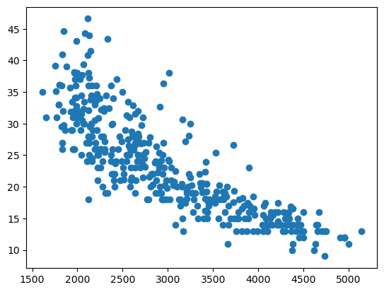

```python
plt.scatter(x = carfeatures['weight'], y = carfeatures['mpg'])
plt.show()
```

**Q**: Is this a good plot?

```python
# Try another scatter plot with x = "acceleration"
```

# Pro Tips: How to be a great student for DATASCI 151?

- Ask clarifying questions, e.g.
  - Can you explain what this command is doing? --> **I don't mind repeating an explanation!**
  - What are the arguments of this function?
  - What is the output?
  - I get an error saying .... (be explicit), what could be the issue?
- Remember that good coders ...
  - build up their toolkit of commands over time
  - understand that errors are normal the first time you run a command
  - **learn to use online websites to interpret errors!!**, https://stackoverflow.com/questions/tagged/python
  - search help pages to find proper syntax, e.g. https://www.w3schools.com/python/
- Experiment
  - If we do analyses for variable "A", try it for "B"
  - Search online how to do something extra, e.g. change the color of a scatter plot
  - Try running the syntax deliberately wrong: helps you get more familiar with error messages
  - Think long term: Figuring out a puzzle today, means that you can use the code for the next time!
- Come to office hours
  - Best time for a one-on-one!
  - Good place to ask about topics not covered in the lecture